# Les tweets et leurs réseaux

SB

23/04/2020

```r
#knitr::opts_chunk$set(echo = FALSE)
library(tidyverse) #l'environnement de base : données et visus
library(igraph) #pour l'analyse de réseau
library(tidytext) #pour gérer les mots
library(emo) #pour gérer les émojis
library(ggplot2) #pour les graphiques
library(widyr) #pour certaines manipulations
library(wordcloud) #pour les nuages de mots
library(threejs) #pour les représentations 3d
library(htmlwidgets) #pour les fichiers html
library(readr) #pour les fichiers rds
library(RColorBrewer) #pour les palettes de couleurs
```

L’objectif de ce document est de montrer la procédure pour transformer un corpus de tweets en différents réseaux : celui des hashtags, celui des mentions et celui des émojis. Le corpus a été créé grâce à rtweet, le traitement des données grâce au tidyverse et la réalisation des réseaux grâce à igraph. La représentation 3D des réseaux a été réalisé grâce au package threejs. Le graphe est enregistré au format html, et est visible dans R mais pas avec knittr.

# Data

Le jeu de données utilisé est une extraction de tweets #confinement réalisé grâce à rtweet, comprenant les variables “status_id”, “is_retweet”, “text”, “hashtags” et “mentions_screen_name”.

```r
tweets<-read_rds("df_confinement21042020.rds")
```

# Hashtags

## Constitution des données

La variable hashtags contient des listes des hashtags mentionnés dans chacun des tweets. La première chose est de transformer les listes en autant de lignes que nécessaire pour ensuite pouvoir manipuler les données.

```r
hash<-tweets%>%
  filter(is_retweet==F)%>% #on évacue les retweets
  subset(select=c("status_id","hashtags")) #on ne retient que les variables qui nous intéressent
hash<-unique(hash) #on supprime les doublons

#on transforme les données en dataframe
hash_2<-as.data.frame(unlist(hash[["hashtags"]]))
foo<- sapply(hash$hashtags, length)
foo2 <- as.data.frame(rep(hash$status_id, times=foo))
foo2<-cbind(foo2,hash_2)
foo2$id<-foo2[,1]
foo2$hashtag<-foo2[,2]
foo3<-foo2[,3:4]

#On calcule les fréquences d'apparition des hashtags
frq <- foo3 %>%
  group_by(hashtag) %>%
  summarise(freq=n()) %>%
  arrange(desc(freq))
frq
```

```
## # A tibble: 36,253 x 2
##    hashtag         freq
##    <fct>          <int>
##  1 confinement    40583
##  2 Confinement     8288
##  3 coronavirus     5539
##  4 COVID19         5420
##  5 Covid_19        3048
##  6 Coronavirus     2053
##  7 covid19         1955
##  8 RestezChezVous  1657
##  9 COVIDー19       1655
## 10 Covid19         1115
## # ... with 36,243 more rows
```

```r
#On calcule les cooccurrences entre les hashtags
cooc <- foo3 %>%
  pairwise_count(hashtag, feature = id,sort=T)
cooc
```

```
## # A tibble: 598,016 x 3
##    item1       item2           n
##    <fct>       <fct>       <dbl>
##  1 coronavirus confinement  5180
##  2 confinement coronavirus  5180
##  3 COVID19     confinement  4697
##  4 confinement COVID19      4697
##  5 Covid_19    confinement  2661
##  6 confinement Covid_19     2661
##  7 covid19     confinement  1877
##  8 confinement covid19      1877
##  9 COVIDー19   confinement  1517
## 10 confinement COVIDー19    1517
## # ... with 598,006 more rows
```

## Réseau simple

La première représentation que l’on fait est un réseau simple, en deux dimensions. On commence par filtrer les données pour ne pas avoir un graphique illisible, ici on ne retient que les cooccurrences fréquentes. On crée ensuite un fichier vertex pour entrer différentes caractéristiques associés à chaque hashtags, ce qui nous permet de personnaliser la représentation graphique. On crée ensuite le graph et on le représente.

```r
#filtrer les cooccurrences
cooc2 <- cooc %>%
  filter(n > 133)

#Pour chaque hashtag, on associe sa fréquence d'apparition dans le corpus
vertex<-cooc2%>%select(item1)%>%unique()%>% inner_join(frq, by=c("item1"="hashtag"))

#On sépare en 5 groupes selon la fréquence d'apparition, pour associer les couleurs et les tailles
vertex<-vertex%>%mutate(type=cut(freq,quantile(vertex$freq,  probs = seq(0,        1, by=0.20)), labels=F,include.lowest = T))
#on crée la palettes
palette<-tibble(color=brewer.pal(5,"BuPu"), type=c(1,2,3,4,5))

#on joint la palette aux donénes
vertex<-inner_join(vertex, palette)
```

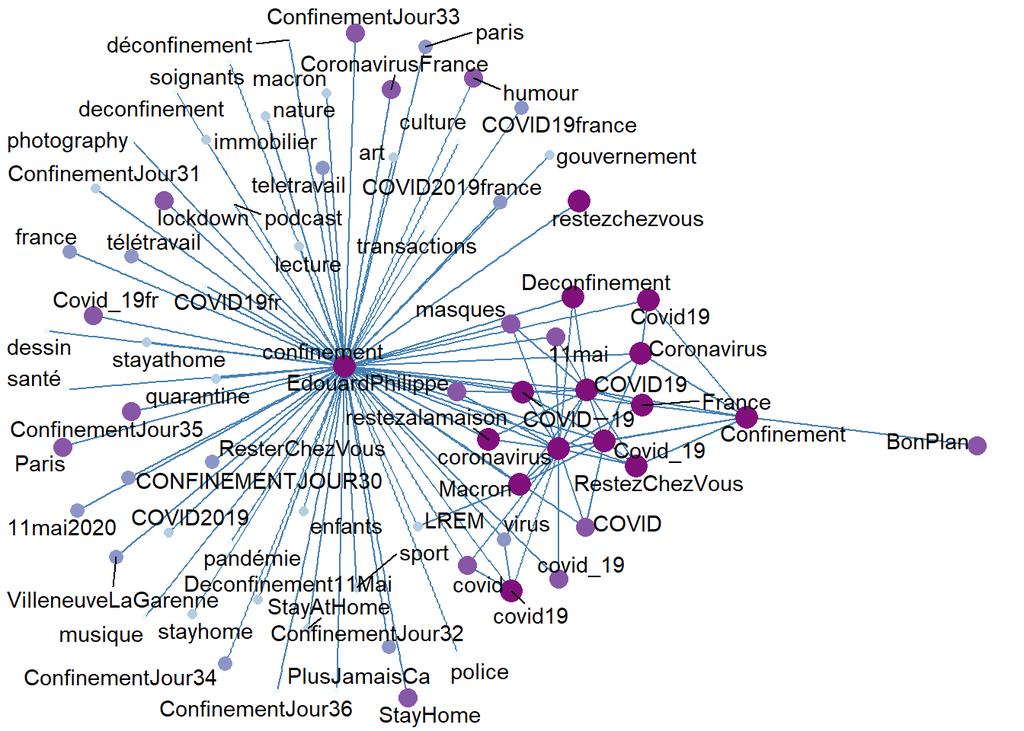

```r
#on crée l'objet graph
hash_graph<-graph_from_data_frame(cooc2, vertices = vertex)

#Représentation graphique
hash_graph %>%
  ggraph::ggraph(layout = "fr") +   #forme du graphe
  ggraph::geom_edge_link(edge_colour="steelblue") + #couleur des liens
  ggraph::geom_node_point(color = V(hash_graph)$color, size = V(hash_graph)$type) + #couleur et taille des points
  ggraph::geom_node_text(aes(label = name), repel = TRUE) + #affichage du texte
  ggplot2::theme_void() #thème vide
```

## Wordcloud selon la centralité

On fait une représentation des hashtags les plus centraux dans le graphe (les hubs), grâce à un wordcloud.

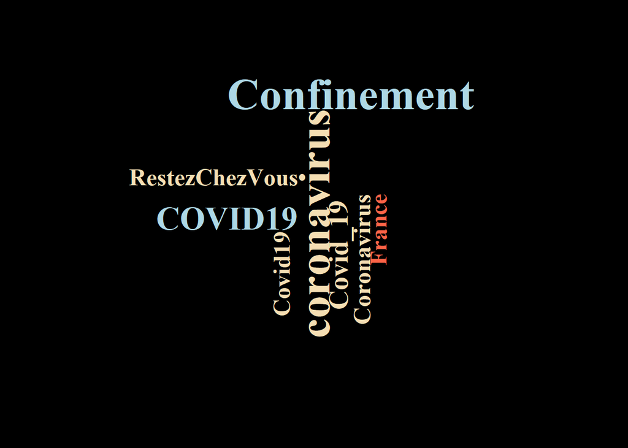

```r
p.rank <- sort(betweenness(hash_graph, directed = TRUE), decreasing = TRUE)[-1] #on calcule la centralité
p.rank <- sqrt(p.rank[p.rank > 0]) #on change d'échelle et on supprime les 0
#représentation graphique
par(bg = "black") #option graphique
wordcloud(names(p.rank), p.rank, colors = c("tomato", "wheat", "lightblue"),
          scale = c(3, 0.5), random.color = TRUE, rot.per = 0.5, random.order = F,font = 2,
          family = "serif") #le nuage de mots
```

## Réseau en 3D

```r
#on filtre, mais moins
cooc3 <- cooc %>%
  filter(n > 33)

#même procédure que précédemment
vertex<-cooc3%>%select(item1)%>%unique()%>% inner_join(frq, by=c("item1"="hashtag"))

vertex<-vertex%>%mutate(type=cut(freq,quantile(vertex$freq,  probs = seq(0,        1, by=0.20)), labels=F,include.lowest = T),
                        size=type/10)
palette<-tibble(color=brewer.pal(5,"BuPu"), type=c(1,2,3,4,5))
vertex<-inner_join(vertex, palette)
```

```r
hash_graph<-graph_from_data_frame(cooc2, vertices = vertex)

#on crée l'objet graphe en 3d grâce à threejs
gjs <- graphjs(hash_graph,layout = layout_with_fr(hash_graph, dim=3), #la forme du graphe, en 3d
               vertex.color = "lightblue", #la couleur des noeuds
               vertex.size = V(hash_graph)$size,#la taille des noeuds
               vertex.shape = "square", #la forme des noeuds
               edge.color = "grey", #la couleur des liens
               edge.width = 2, #la taille des liens
               main="réseau des #", bg="gray10",  #le titre
               curvature=0.1, attraction=0.9, repulsion=0.8, opacity=0.9)%>% #les paramètres du graphe
  points3d(vertices(.), color=V(hash_graph)$color, pch=V(hash_graph)$name, size=0.1) #l'affichage des mots associés aux noeuds
#print(gjs) #l'affichage du graphe mais pas dans un markdown
saveWidget(gjs, file="Hashtag-Network-gjs3.html") #sauvegarder le graphe en html
browseURL("Hashtag-Network-gjs3.html") #ouvrir le fichier html
```

## Sans #confinement

On reprend les mêmes procédures que précédemment, mais on enlève la référence au hashtag confinement.

```r
cooc2bis <- cooc %>%
  filter(item1!="confinement"&item2!="confinement"&n>51)

vertex2<-cooc2bis%>%select(item1)%>%unique()%>% inner_join(frq, by=c("item1"="hashtag"))

vertex2<-vertex2%>%mutate(type=cut(freq,quantile(vertex$freq,  probs = seq(0,        1, by=0.20)), labels=F,include.lowest = T),
                        size=type/10)
palette<-tibble(color=brewer.pal(5,"BuPu"), type=c(1,2,3,4,5))
vertex2<-inner_join(vertex2, palette)
```

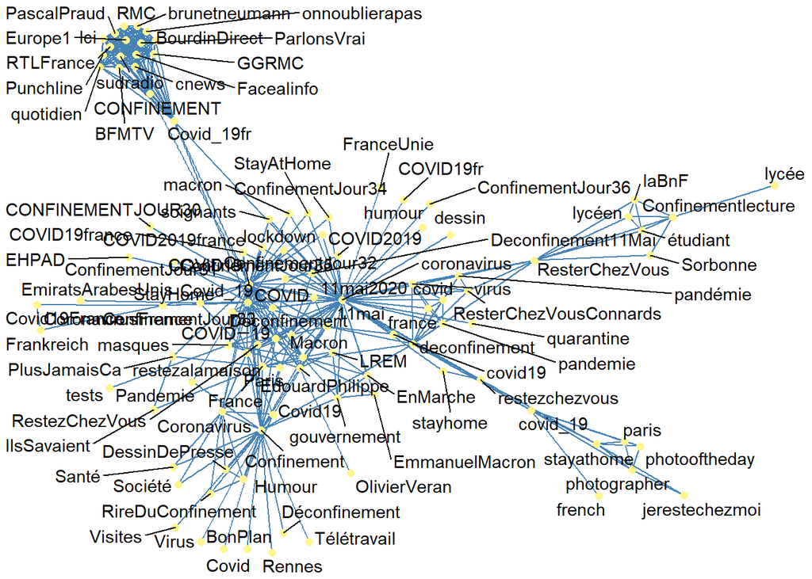

```r
hash_graph2<-graph_from_data_frame(cooc2bis, vertices = vertex2)

hash_graph2 %>%
  ggraph::ggraph(layout = "fr") +
  ggraph::geom_edge_link(edge_colour="steelblue") +
  ggraph::geom_node_point(color = "khaki1", size = 2) +
  ggraph::geom_node_text(aes(label = name), repel = TRUE) +
  ggplot2::theme_void()
```

```r
gjs2 <- graphjs(hash_graph2,layout = layout_with_fr(hash_graph2, dim=3),
               vertex.color = "lightblue",
               vertex.size = V(hash_graph2)$size,
               vertex.shape = "square",
               edge.color = "grey",
               edge.width = 2,
               main="réseau des # sans #confinement", bg="gray10",
               curvature=0.1, attraction=0.9, repulsion=0.8, opacity=0.9)%>%
  points3d(vertices(.), color=V(hash_graph2)$color, pch=V(hash_graph2)$name, size=0.1)
#print(gjs)
saveWidget(gjs2, file="Hashtag-Network-gjs4.html")
browseURL("Hashtag-Network-gjs4.html")
```

# Réseau des mentions

On réitère la même procédure, mais sur les mentions cette fois.

```r
mention<-tweets%>%filter(is_retweet==F)%>%subset(select=c("status_id","mentions_screen_name"))
mention<-unique(mention)

mention2<-as.data.frame(unlist(mention[["mentions_screen_name"]]))
foo<- sapply(mention$mentions_screen_name, length)
foo2 <- as.data.frame(rep(mention$status_id, times=foo))
foo2<-cbind(foo2,mention2)
foo2$id<-foo2[,1]
foo2$mention<-foo2[,2]
foo3<-foo2[,3:4]

ment<-foo3%>%
  group_by(id) %>%
  summarise(catY = toString(mention))

df_tok<-ment%>%unnest_tokens(output = "mention", input=catY)

frq <- df_tok %>%
  group_by(mention) %>%
  summarise(freq=n()) %>%
  arrange(desc(freq))

cooc <- df_tok %>%
  pairwise_count(mention, feature = id,sort=T)
```

## Réseau simple

```r
cooc2 <- cooc %>%
  filter(n > 11)

vertex<-cooc2%>%select(item1)%>%unique()%>% inner_join(frq, by=c("item1"="mention"))

vertex<-vertex%>%mutate(type=cut(freq,quantile(vertex$freq,  probs = seq(0,        1, by=0.20)), labels=F,include.lowest = T))
palette<-tibble(color=brewer.pal(5,"OrRd"), type=c(1,2,3,4,5))
vertex<-inner_join(vertex, palette)
```

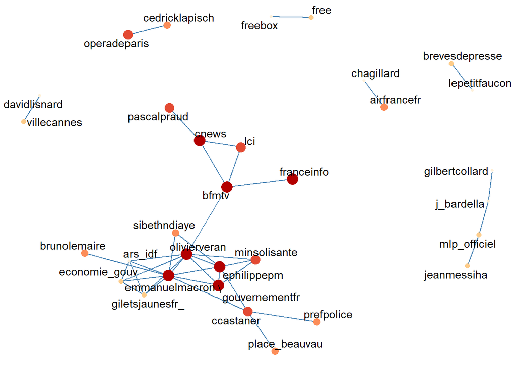

```r
mention_graph<-graph_from_data_frame(cooc2, vertices = vertex)



mention_graph %>%
  ggraph::ggraph(layout = "fr") +
  ggraph::geom_edge_link(edge_colour="steelblue") +
  ggraph::geom_node_point(color = V(mention_graph)$color, size = V(mention_graph)$type) +
  ggraph::geom_node_text(aes(label = name), repel = TRUE) +
  ggplot2::theme_void()
```

## Wordcloud selon la centralité

[figure not shown]

```r
p.rank <- sort(betweenness(mention_graph, directed = TRUE), decreasing = TRUE)[-1]
p.rank <- sqrt(p.rank[p.rank > 0])
par(bg = "black")
wordcloud(names(p.rank), p.rank, colors = c("tomato", "wheat", "lightblue"),
          scale = c(3, 0.5), random.color = TRUE, rot.per = 0.5, random.order = F,font = 2,
          family = "serif")
```

## Réseau en 3D

```r
cooc3 <- cooc %>%
  filter(n > 3)

vertex<-cooc3%>%select(item1)%>%unique()%>% inner_join(frq, by=c("item1"="mention"))

vertex<-vertex%>%mutate(type=cut(freq,quantile(vertex$freq,  probs = seq(0,        1, by=0.20)), labels=F,include.lowest = T),
                        size=type/10)
palette<-tibble(color=brewer.pal(5,"OrRd"), type=c(1,2,3,4,5))
vertex<-inner_join(vertex, palette)
```

```r
mention_graph<-graph_from_data_frame(cooc3, vertices = vertex)

gjs <- graphjs(mention_graph,layout = layout_with_fr(mention_graph, dim=3),
               vertex.color = "lightblue",
               vertex.size = V(mention_graph)$size,
               vertex.shape = "square",
               edge.color = "grey",
               edge.width = 2,
               main="Réseau des mentions @", bg="gray10",
               curvature=0.1, attraction=0.9, repulsion=0.8, opacity=0.9)%>%
  points3d(vertices(.), color=V(mention_graph)$color, pch=V(mention_graph)$name, size=0.1)
#print(gjs)
saveWidget(gjs, file="Mention-Network-gjs3.html")
browseURL("Mention-Network-gjs3.html")
```

# Emojis

Pour finir, on fait la même chose avec les émojis. Pour cela, on commence par les extraires des twwets, grâce au package emo, puis on applique toujours la même procédure.Il faut encore trouver comment insérer de jolies images d’émojis…

```r
emojis <- tweets %>%
mutate(emoji = emo::ji_extract_all(text)) %>% #on récupère la liste des émojis pour chaque tweet, c'est un peu long
select(status_id, emoji)

emojis2<-as.data.frame(unlist(emojis[["emoji"]]))
foo<- sapply(emojis$emoji, length)
foo2 <- as.data.frame(rep(emojis$status_id, times=foo))
foo2<-cbind(foo2,emojis2)
foo2$id<-foo2[,1]
foo2$emoji<-foo2[,2]
foo3<-foo2[,3:4]

frq <- foo3 %>%
  group_by(emoji) %>%
  summarise(freq=n()) %>%
  arrange(desc(freq))

cooc <- foo3 %>%
  pairwise_count(emoji, feature = id,sort=T)
```

## Réseau simple

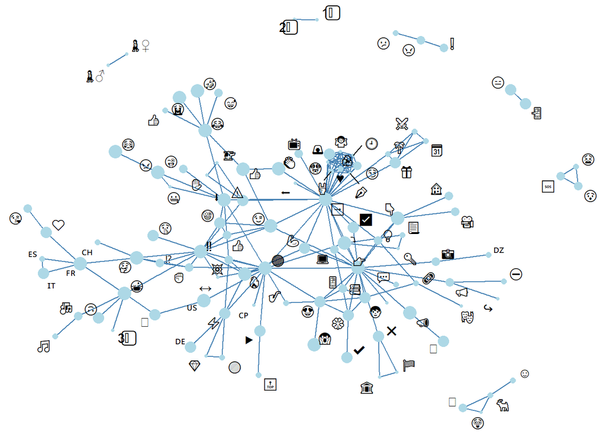

```r
cooc2 <- cooc %>%
  filter(n > 75)

vertex<-cooc2%>%select(item1)%>%unique()%>% inner_join(frq, by=c("item1"="emoji"))

vertex<-vertex%>%mutate(type=cut(freq,quantile(vertex$freq,  probs = seq(0,1, by=0.20)), labels=F,include.lowest = T))
emo_graph<-graph_from_data_frame(cooc2, vertices = vertex)


emo_graph %>%
  ggraph::ggraph(layout = "fr") +
  ggraph::geom_edge_link(edge_colour="steelblue") +
  ggraph::geom_node_point(color="lightblue", size = V(emo_graph)$type) +
  ggraph::geom_node_text(aes(label = name), repel = TRUE) +
  ggplot2::theme_void()
```

## Wordcloud selon la centralité

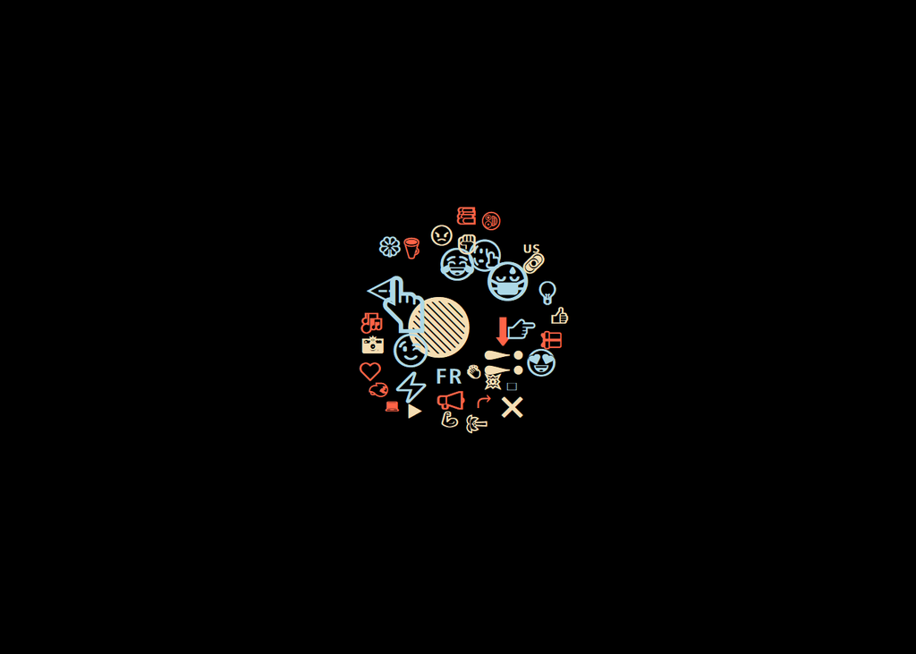

```r
p.rank <- sort(betweenness(emo_graph, directed = TRUE), decreasing = TRUE)[-1]
p.rank <- sqrt(p.rank[p.rank > 0])
par(bg = "black")
wordcloud(names(p.rank), p.rank, colors = c("tomato", "wheat", "lightblue"),
          scale = c(3, 0.5), random.color = TRUE, rot.per = 0.5, random.order = F,font = 2,
          family = "serif")
```

## Réseau en 3D

```r
cooc3 <- cooc %>%
  filter(n > 36)

vertex<-cooc3%>%select(item1)%>%unique()%>% inner_join(frq, by=c("item1"="emoji"))

vertex<-vertex%>%mutate(color=cut(freq,quantile(vertex$freq,  probs = seq(0,        1, by=0.25)), labels=F,include.lowest = T),
                        size=color/10)

emo_graph<-graph_from_data_frame(cooc3, vertices = vertex)

gjs <- graphjs(emo_graph,layout = layout_with_fr(emo_graph, dim=3),
               vertex.color = "lightblue",
               vertex.size = V(emo_graph)$size,
               vertex.shape = "square",
               edge.color = "grey",
               edge.width = 2,
               main="Réseau des Emojis", bg="gray10",
               curvature=0.1, attraction=0.9, repulsion=0.8, opacity=0.9)%>%
  points3d(vertices(.),  pch=V(emo_graph)$name, size=0.1)
#print(gjs)
saveWidget(gjs, file="Emoji-Network3.html")
browseURL("Emoji-Network3.html")
```